# Fitness Activity

Uttam Reddy

11/06/2020

## Course project 2

### Loading and processing the data

Let’s load the *activity.csv* data file into a data frame variable called *fitdata* and transforming the *date* character variable to **date** format

```r
# read the dataset
fitdata <- read.csv(file = "activity.csv", header = TRUE, sep = ",", colClasses = c("integer", "character", "integer"))
# transforming date variable
fitdata <- transform(fitdata, date = as.Date(fitdata$date, "%Y-%m-%d"))
```

### What is the mean total number of steps taken per day

The following code estimates the mean total number of steps taken per day

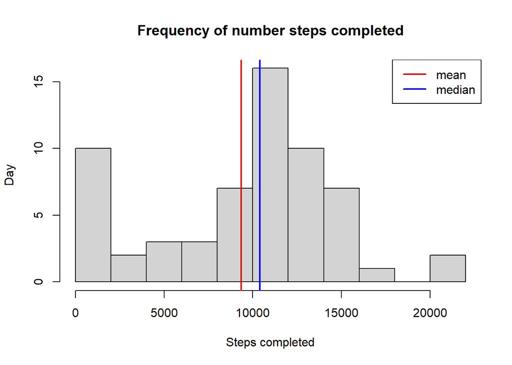

```r
# adding the steps according to the date variable
stepVdate <- with(fitdata, tapply(steps,date , sum, na.rm = T))
# making a histogram or bar plot of total number of steps taken per day
hist(stepVdate, breaks = 11, xlab = "Steps completed", ylab = "Day", main = "Frequency of number steps completed")
abline(v = mean(stepVdate, na.rm = T), lwd = 2, lty = 1, col = "red")
abline(v = median(stepVdate, na.rm = T), lwd = 2, lty = 1, col = "blue")
legend("topright", legend = c("mean", "median"), col = c("red","blue"), lwd = 2)
```

```r
# calculating the mean, median, and total step counts
stepmean <- mean(stepVdate, na.rm = T)
stepmedian <- median(stepVdate, na.rm = T)
total.steps <- sum(fitdata$steps, na.rm = T)
```

The mean steps per day is 9354.2295082 and the median steps per day is 10395.

### What is the average daily activity pattern?

The following code estimates the daily activity pattern

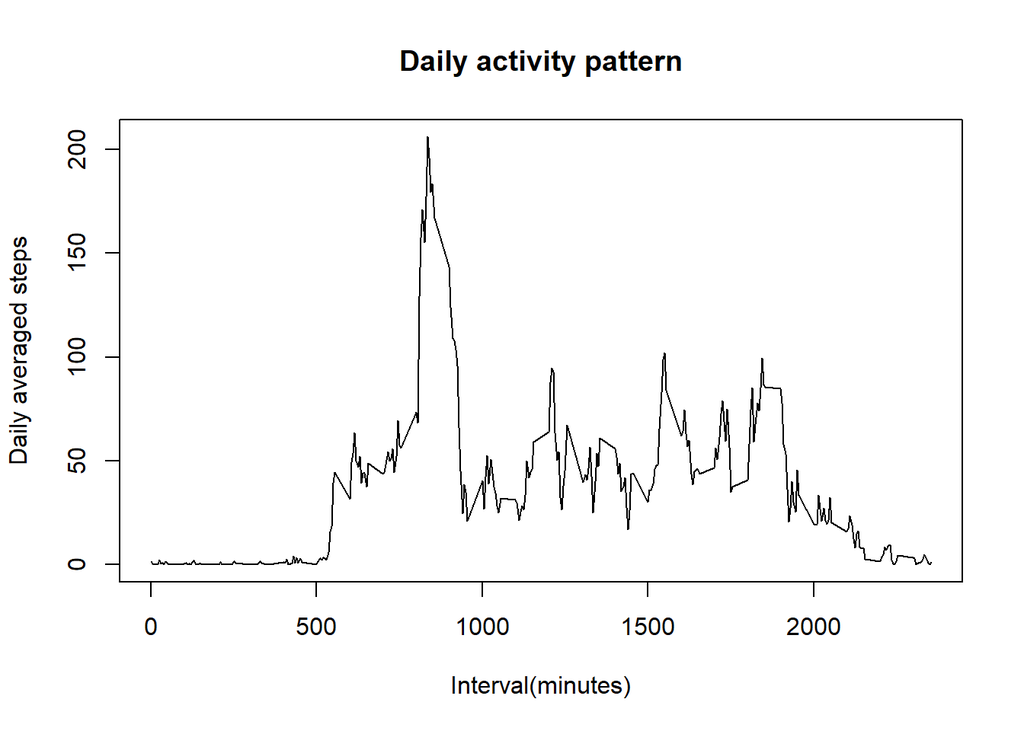

```r
# calculating the daily averaged steps according to the time interval
stepVinterval <- aggregate(steps~interval, data = fitdata, mean)
#plotting
with(stepVinterval, plot(interval, steps, xlab = "Interval(minutes)", ylab = "Daily averaged steps", main = "Daily activity pattern", type = "l"))
```

```r
# estimating the interval at which maximum steps took place
max_stepinterval <- stepVinterval[which.max(stepVinterval$steps), ][1]
```

The maximum step inteval averaged across all the days is 835.

### Imputing missing values

The total number of rows with missing values in the data

```r
tot_NA <- sum(is.na(fitdata$steps))
```

The total number of missing values is given as 2304.

Filling the missing data with mean of the interval

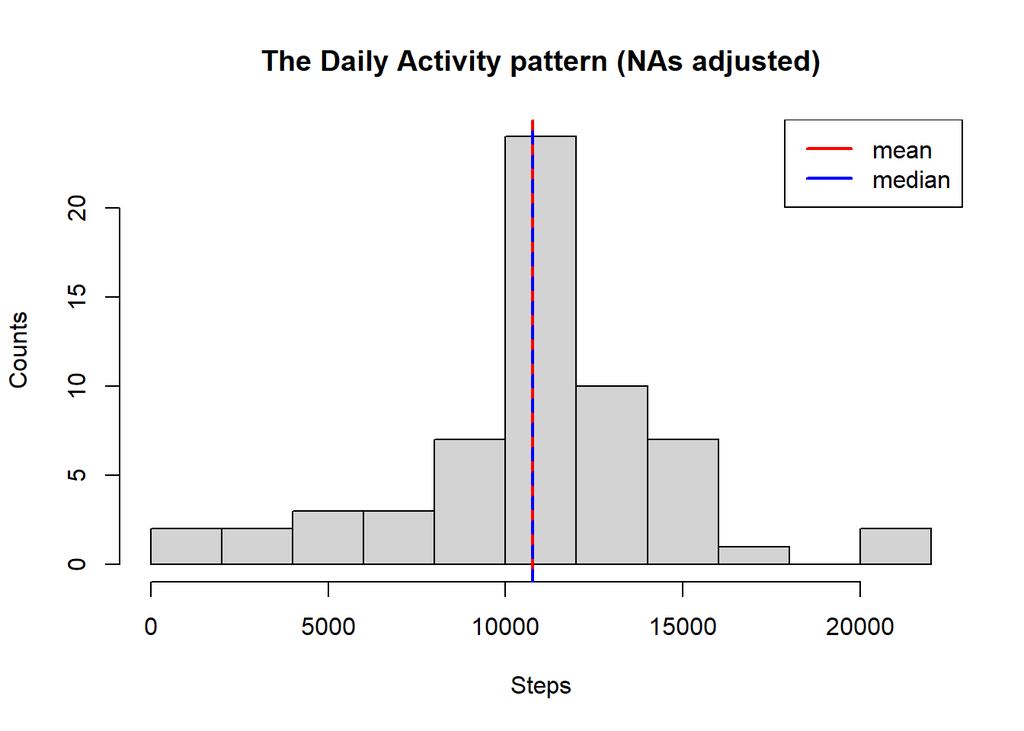

```r
# creating a vector containing the average step counts according to a given interval
mean.steps <- with(fitdata, tapply(steps, interval, mean, na.rm=T))
# creating an imputed dataset by assigning the average step count in the interval to the missing values
impute_fitdata <- transform(fitdata, steps = ifelse(is.na(steps), mean.steps, steps))
stepVdate2 <- aggregate(steps~date, data = impute_fitdata, sum)
#plotting
with(stepVdate2, hist(steps, breaks = 11, xlab = "Steps", ylab = "Counts", main = "The Daily Activity pattern (NAs adjusted)"))
abline(v = mean(stepVdate2$steps), lwd =2, col = "red")
abline(v = median(stepVdate2$steps), lwd = 2, lty = 2,  col = "blue")
legend("topright", legend = c("mean", "median"), col=c("red","blue"), lwd = 2)
```

```r
# calculating the mean, median and total steps in the imputed data set
mean.steps_impute_fitdata <- mean(stepVdate2$steps)
median.steps_impute_fitdata <- median(stepVdate2$steps)
total.steps_impute_fitdata <- sum(stepVdate2$steps)
```

### Are there differences in activity patterns between weekdays and weekends?

The following code estimates the differences in activity patterns between weekdays and weekends

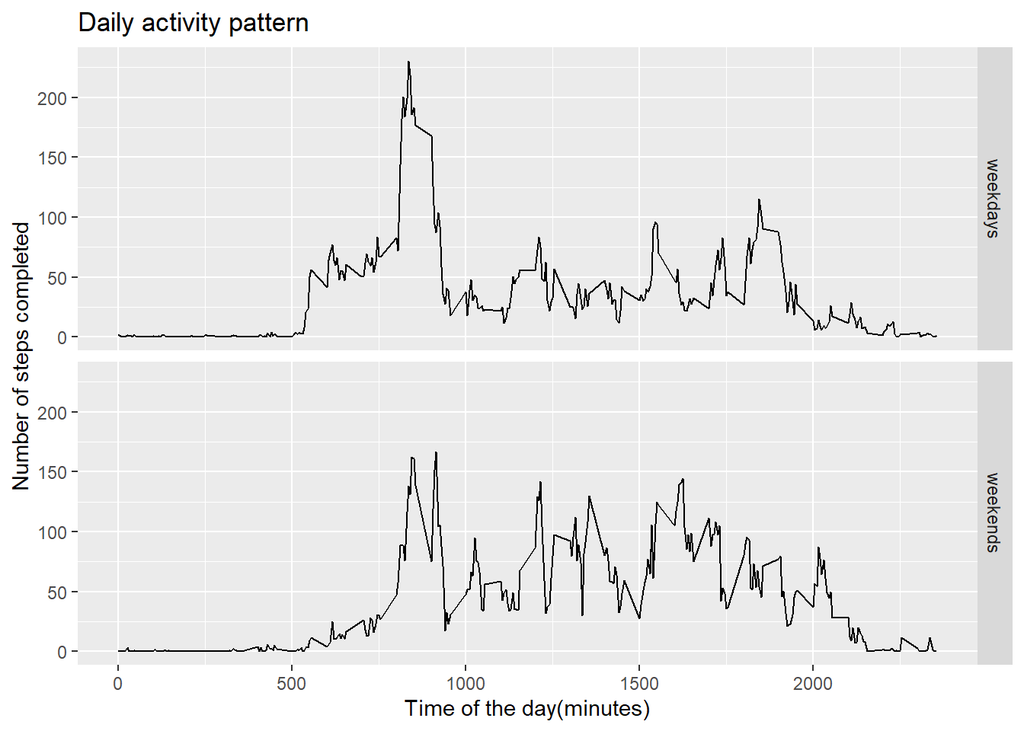

```r
## adding a weekday factor variable to the imputed dataset
impute_fitdata <- transform(impute_fitdata, week = factor(weekdays(date)))
levels(impute_fitdata$week) <- c("weekdays", "weekdays","weekends","weekends","weekdays", "weekdays","weekdays")
# calculating the averaged step count according to the interval and week
stepVinterval2 <- aggregate(steps~interval+week, data = impute_fitdata, mean)
## plotting
library(ggplot2)
g <- ggplot(data = stepVinterval2, aes(x = interval, y = steps))
g + geom_line() + facet_grid(week~.) + labs(x = "Time of the day(minutes)", y = "Number of steps completed", title = "Daily activity pattern")
```

Thus, we can observe that activity is highest at the early hours of the weekdays. However, on an average, activity is greater on weekends.